# gi-ws-04-1

Jana Schönemann, Agnes Schneider, Kevin Frac, Sebastian Richter

22 Nocember 2016

## Workflow

source(“D:/BEN/richters/msc-phygeo-class-of-2016-richte4d/fun/rs_source_richters.R”)

### Compute

dem_fp <- paste0(path_input, “las_dsm_01m.tif”)

### Transform tif to sgrd

cmd.tif2sgrd <- paste0(path_saga, " io_gdal 0“,” -GRIDS “, paste0(dem_fp,”.sgrd“),” -FILES “, dem_fp) system(cmd.tif2sgrd)

### Compute slope

cmd.all_in_1 <- paste0(path_saga, " ta_morphometry 0“,” -ELEVATION “, paste0(dem_fp,”.sgrd“),” -SLOPE “, paste0(path_temp,”slope.sgrd“),” -C_MINI “, paste0(path_temp,”mincurv.sgrd“),” -C_MAXI “, paste0(path_temp,”maxcurv.sgrd“),” -C_PROF “, paste0(path_temp,”pcurv.sgrd“),” -C_TANG “, paste0(path_temp,”tcurv.sgrd“)) system(cmd.all_in_1)

cmd.fuzzy <- paste0(path_saga, " ta_morphometry 25“,” -SLOPE “, paste0(path_temp,”slope.sgrd“),” -MINCURV “, paste0(path_temp,”mincurv.sgrd“),” -MAXCURV “, paste0(path_temp,”maxcurv.sgrd“),” -PCURV “, paste0(path_temp,”pcurv.sgrd“),” -TCURV “, paste0(path_temp,”tcurv.sgrd“),” -PLAIN “, paste0(path_output,”plain.sgrd“)) system(cmd.fuzzy)

cmd.sgrd2tif <- paste0(path_saga, " io_gdal 1“,” -GRIDS “, paste0(path_output,”plain.sgrd“),” -FILES “, paste0(path_output,”plain.tif“)) system(cmd.sgrd2tif)

### Es ist nicht nachvollziehbar warum das Umwandeln in TIFF hier nicht funktioniert :(

### Über das Tool in der Sagaoberfläche konnte das TIFF aber exportiert werden :)

```r
source("D:/BEN/richters/msc-phygeo-class-of-2016-richte4d/fun/rs_source_richters.R")
library(raster)
dsm=stack(paste0(path_output, "plain.tif"))
dsm
```

```
## class       : RasterStack
## dimensions  : 4000, 5000, 2e+07, 1  (nrow, ncol, ncell, nlayers)
## resolution  : 1, 1  (x, y)
## extent      : 474000, 479000, 5630000, 5634000  (xmin, xmax, ymin, ymax)
## coord. ref. : NA
## names       : plain
## min values  :     0
## max values  :     1
```

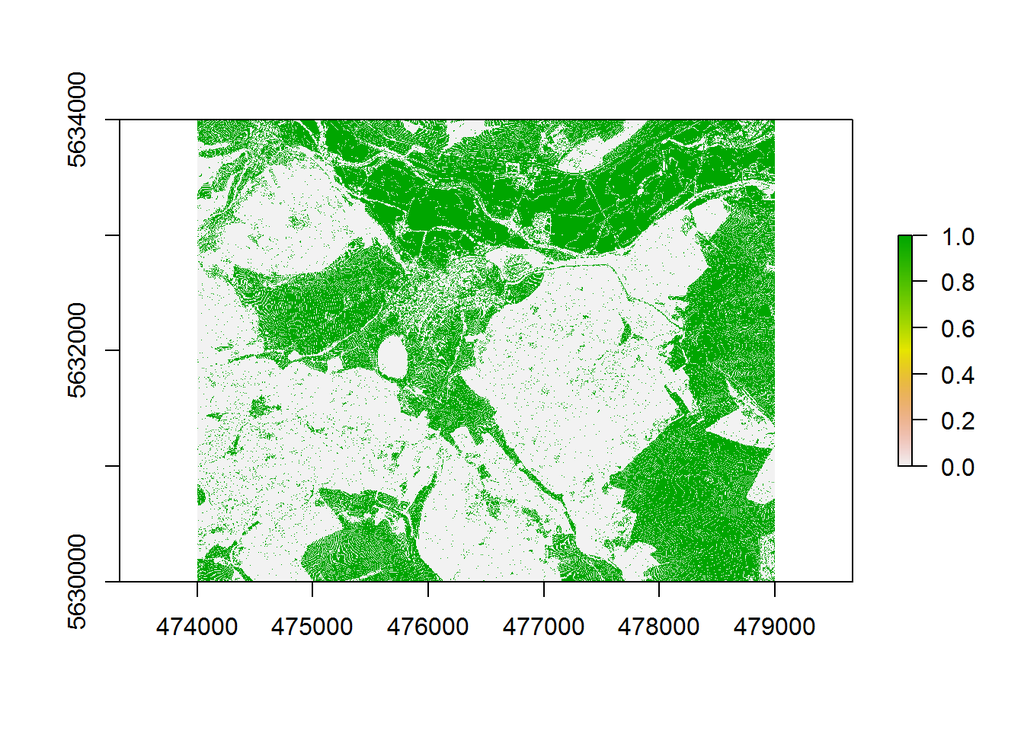

```r
plot(dsm)
```